# ECN 301E Lab #5

The dataset `data-exercise-05-rent.dta` contains information on 1082 randomly selected rental properties in a large German city (Munich) in the year 1994. The information in this dataset is used by the local council to determine average rent levels in the city, which are in turn used in rent control programs.

Start with setting the global path:

```stata
global path "E:\Users\Buğra\Google Drive\TA\ECN 301E\Fall '18\Labs" /* change to whatever makes you happy */
```

Import the [dataset](https://drive.google.com/open?id=1zOVxqje7Irfi0DOuYrj_9t-R7CGT_81e):

```stata
use "$path\Lab 5\data-exercise-05-rent.dta", clear
```

## Looking at the Data

```stata
des
```

```
Contains data from E:\Users\Buğra\Google Drive\TA\ECN 301E\Fall '18\Labs\Lab 5\data-exercise-05-rent.dta
  obs:         1,082
 vars:            10                          29 Oct 2006 19:11
 size:        28,132
---------------------------------------------------------------------------------------------------------------------------------------------------------------------------------------------------------------------------------------------------------------
              storage   display    value
variable name   type    format     label      variable label
---------------------------------------------------------------------------------------------------------------------------------------------------------------------------------------------------------------------------------------------------------------
rent            float   %9.0g                 rent (excluding bills) per month in DM
sqm             int     %8.0g                 size of the flat in square meters
year            float   %9.0g                 year in which the property was built
bath            int     %8.0g                 =1 if flat has no separate bath room
centralheat     int     %8.0g                 =1 if flat has central heating
hotwater        int     %8.0g                 =1 if flat has no central hot water supply
bathtiles       int     %8.0g                 =1 if bathroom walls covered with tiles
kitchen         int     %8.0g                 =1 if the flat has a high-end kitchen
duration        int     %8.0g                 years since the current tenants have moved in
location        float   %9.0g                 =1 if bad location, =2 if average location and =3 if good location
---------------------------------------------------------------------------------------------------------------------------------------------------------------------------------------------------------------------------------------------------------------
Sorted by:
```

```stata
sum
```

```
    Variable |        Obs        Mean    Std. Dev.       Min        Max
-------------+---------------------------------------------------------
        rent |      1,082    830.3258    408.3337     127.06       3130
         sqm |      1,082    69.13031    26.51819         20        250
        year |      1,082    1947.208    31.17086       1800       1992
        bath |      1,082    .0286506    .1668998          0          1
 centralheat |      1,082    .8133087    .3898437          0          1
-------------+---------------------------------------------------------
    hotwater |      1,082    .0554529    .2289679          0          1
   bathtiles |      1,082    .5878004    .4924584          0          1
     kitchen |      1,082    .0942699    .2923389          0          1
    duration |      1,082    10.63124    12.09681          0         82
    location |      1,082    2.211645    .5775104          1          3
```

## Questions

**Generate a variable which contains the rent per square meter. Generate a scatter plot of this variable against the variable `sqm`. Propose an economic explanation for the observed relationship.**

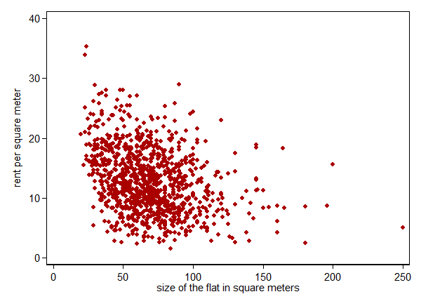

```stata
gen rentp2m = rent/sqm
lab var rentp2m "rent per square meter"

graph twoway scatter rentp2m sqm, scheme(s1color) mcolor(red*1.5) ylabel(,angle(0))
```

Rent seems to be decreasing in the size of the apartment. The effect is stronger for small flats and tampers out as size increasing possible economic explanations: fixed costs i.e. landlord needs to install kitchen/bathroom, but only one per flat.

**Regress the rent per square meter on `sqm` and `year` and the square of these two variables. Do the results confirm your expectations? Compute at which value of `sqm` the rent per square meter reaches a minimum.**

```stata
gen yearsq = year^2
gen sqmsq = sqm^2

reg rentp2m sqm sqmsq year yearsq
```

```
      Source |       SS           df       MS      Number of obs   =     1,082
-------------+----------------------------------   F(4, 1077)      =     65.00
       Model |  5803.89507         4  1450.97377   Prob > F        =    0.0000
    Residual |  24040.7603     1,077  22.3219687   R-squared       =    0.1945
-------------+----------------------------------   Adj R-squared   =    0.1915
       Total |  29844.6553     1,081  27.6083768   Root MSE        =    4.7246

------------------------------------------------------------------------------
     rentp2m |      Coef.   Std. Err.      t    P>|t|     [95% Conf. Interval]
-------------+----------------------------------------------------------------
         sqm |  -.1556477   .0179124    -8.69   0.000    -.1907948   -.1205007
       sqmsq |   .0005919   .0001006     5.88   0.000     .0003945    .0007894
        year |  -3.840047   .5716279    -6.72   0.000    -4.961677   -2.718416
      yearsq |   .0010019   .0001478     6.78   0.000     .0007119    .0012919
       _cons |   3697.795   552.6552     6.69   0.000     2613.392    4782.198
------------------------------------------------------------------------------
```

Expectation:

Rent decreases in size but the effect is stronger for smaller flats i.e. the coefficient on `sqm` should be negative and the coefficient on `sqmsq` positive. This is the case.

The approximate marginal effect of a one sqm increase is:

$$ \dfrac{\partial{(rentp2m)}}{\partial{(sqm)}} = \beta_{sqm} + 2\beta_{sqm}(sqm) $$

The minimum is reached when the marginal effect is $0$:

$$ 0 = \beta_{sqm} + 2\beta_{sqm}(sqm) $$

So,

$$ sqm = \dfrac{-\beta_{sqm}}{2\beta_{sqm}} $$

```stata
display "minimum for sqm at: " ((-1)*_b[sqm])/(2*_b[sqmsq])
```

```
minimum for sqm at: 131.47141
```

The rent per square meter decreases in size until the flat is $131.5$ $m^2$ and increases thereafter.

```stata
display "minimum for year at: " ((-1)*_b[year])/(2*_b[yearsq])
```

```
minimum for year at: 1916.4121
```

We see the same pattern for the year the building was built as for the size of a flat. Here the minimum is $1916.4$ so for all buildings newer than $1916$ the prize is increasing.

**Include the dummy variable `centralheat` in the regression. What is the interpretation of the regression coefficient of this variable?**

```stata
reg rentp2m sqm sqmsq year yearsq centralheat
```

```
      Source |       SS           df       MS      Number of obs   =     1,082
-------------+----------------------------------   F(5, 1076)      =     78.49
       Model |  7976.45386         5  1595.29077   Prob > F        =    0.0000
    Residual |  21868.2015     1,076  20.3236073   R-squared       =    0.2673
-------------+----------------------------------   Adj R-squared   =    0.2639
       Total |  29844.6553     1,081  27.6083768   Root MSE        =    4.5082

------------------------------------------------------------------------------
     rentp2m |      Coef.   Std. Err.      t    P>|t|     [95% Conf. Interval]
-------------+----------------------------------------------------------------
         sqm |  -.1585585   .0170941    -9.28   0.000       -.1921    -.125017
       sqmsq |   .0005832    .000096     6.07   0.000     .0003948    .0007716
        year |  -3.843262   .5454409    -7.05   0.000     -4.91351   -2.773013
      yearsq |   .0009971    .000141     7.07   0.000     .0007204    .0012738
 centralheat |   4.017117   .3885341    10.34   0.000     3.254747    4.779487
       _cons |   3719.296   527.3413     7.05   0.000     2684.563     4754.03
------------------------------------------------------------------------------
```

Conditional on the size and the age of a building having central heating increases the prize for a flat on average by $€4.02$ per sqm i.e. if we compare to flats with exactly the same size and the same age, one with central heating the other without, on average the flat with central heating will have a rent per sqm that is $€4.02$ higher.

**Inspect the variable `location`. How could you include the information contained in this variable in the regression? How plausible are alternative ways of doing this?**

```stata
tab location
```

```
  =1 if bad |
  location, |
      =2 if |
    average |
   location |
  and =3 if |
       good |
   location |      Freq.     Percent        Cum.
------------+-----------------------------------
          1 |         90        8.32        8.32
          2 |        673       62.20       70.52
          3 |        319       29.48      100.00
------------+-----------------------------------
      Total |      1,082      100.00
```

`location` is a categorical variable with $3$ values. We can construct dummy variables for each value:

```stata
tab location, gen(loc_d)
```

```
  =1 if bad |
  location, |
      =2 if |
    average |
   location |
  and =3 if |
       good |
   location |      Freq.     Percent        Cum.
------------+-----------------------------------
          1 |         90        8.32        8.32
          2 |        673       62.20       70.52
          3 |        319       29.48      100.00
------------+-----------------------------------
      Total |      1,082      100.00
```

The generate option creates a dummy for each category of location. To avoid the "dummy variable trap", i.e. adding perfectly colinear variables to our regression we need to either drop one category or remove the constant from our regression. The constant term (or intercept) is a regressor that does not vary, i.e. a regressor that is 1 for each observation. The sum of the three dummy variables is also equal to 1 for all observations (remember each observation falls exactly in 1 category) therefore the intercept and the 3 dummies are perfectly colinear. To account for this we can either drop the intercept (something we usually do not do) or one of the dummy variable categories and interpret the coefficient estimates for our other dummies with respect to that category.

```stata
reg rentp2m sqm sqmsq year yearsq centralheat loc_d2 loc_d3
```

```
      Source |       SS           df       MS      Number of obs   =     1,082
-------------+----------------------------------   F(7, 1074)      =     63.09
       Model |  8696.65775         7  1242.37968   Prob > F        =    0.0000
    Residual |  21147.9976     1,074   19.690873   R-squared       =    0.2914
-------------+----------------------------------   Adj R-squared   =    0.2868
       Total |  29844.6553     1,081  27.6083768   Root MSE        =    4.4374

------------------------------------------------------------------------------
     rentp2m |      Coef.   Std. Err.      t    P>|t|     [95% Conf. Interval]
-------------+----------------------------------------------------------------
         sqm |  -.1577107   .0168296    -9.37   0.000    -.1907334    -.124688
       sqmsq |    .000558   .0000947     5.89   0.000     .0003723    .0007438
        year |  -4.070604   .5394162    -7.55   0.000    -5.129033   -3.012175
      yearsq |   .0010558   .0001395     7.57   0.000     .0007822    .0013295
 centralheat |   3.785298   .3849676     9.83   0.000     3.029924    4.540672
      loc_d2 |   1.920637   .4983361     3.85   0.000     .9428138    2.898459
      loc_d3 |   3.107908   .5345739     5.81   0.000      2.05898    4.156836
       _cons |   3937.333    521.517     7.55   0.000     2914.025    4960.641
------------------------------------------------------------------------------
```

```stata
reg rentp2m sqm sqmsq year yearsq centralheat location
```

```
      Source |       SS           df       MS      Number of obs   =     1,082
-------------+----------------------------------   F(6, 1075)      =     73.36
       Model |  8670.19018         6   1445.0317   Prob > F        =    0.0000
    Residual |  21174.4652     1,075  19.6971769   R-squared       =    0.2905
-------------+----------------------------------   Adj R-squared   =    0.2866
       Total |  29844.6553     1,081  27.6083768   Root MSE        =    4.4382

------------------------------------------------------------------------------
     rentp2m |      Coef.   Std. Err.      t    P>|t|     [95% Conf. Interval]
-------------+----------------------------------------------------------------
         sqm |  -.1573708   .0168298    -9.35   0.000    -.1903938   -.1243479
       sqmsq |   .0005548   .0000946     5.86   0.000     .0003691    .0007405
        year |  -4.103484   .5387564    -7.62   0.000    -5.160617   -3.046351
      yearsq |   .0010643   .0001393     7.64   0.000      .000791    .0013376
 centralheat |     3.7691   .3847756     9.80   0.000     3.014104    4.524096
    location |   1.413069   .2381048     5.93   0.000     .9458663    1.880272
       _cons |   3968.123   520.8409     7.62   0.000     2946.143    4990.103
------------------------------------------------------------------------------
```

**Include all variables available in the dataset in the regression. Do the coefficients of the variables that were already in the regression change dramatically? Do you have an economic explanation for the coefficient estimate of the variable `duration`?**

```stata
reg rentp2m sqm sqmsq year yearsq bath centralheat hotwater loc_d1 loc_d3 bathtiles kitchen duration
```

```
      Source |       SS           df       MS      Number of obs   =     1,082
-------------+----------------------------------   F(12, 1069)     =     57.29
       Model |  11681.6545        12  973.471211   Prob > F        =    0.0000
    Residual |  18163.0008     1,069  16.9906462   R-squared       =    0.3914
-------------+----------------------------------   Adj R-squared   =    0.3846
       Total |  29844.6553     1,081  27.6083768   Root MSE        =     4.122

------------------------------------------------------------------------------
     rentp2m |      Coef.   Std. Err.      t    P>|t|     [95% Conf. Interval]
-------------+----------------------------------------------------------------
         sqm |  -.1466397   .0158504    -9.25   0.000    -.1777412   -.1155382
       sqmsq |   .0005091   .0000888     5.73   0.000     .0003349    .0006834
        year |  -2.949245    .509214    -5.79   0.000    -3.948417   -1.950073
      yearsq |    .000763   .0001317     5.79   0.000     .0005046    .0010214
        bath |  -1.009484    .804825    -1.25   0.210      -2.5887    .5697318
 centralheat |   2.495451   .4017618     6.21   0.000      1.70712    3.283782
    hotwater |  -1.296533   .6296086    -2.06   0.040    -2.531942   -.0611241
      loc_d1 |  -1.886458   .4646576    -4.06   0.000    -2.798202   -.9747135
      loc_d3 |   1.289247   .2869118     4.49   0.000     .7262732    1.852222
   bathtiles |   .8008364   .2790293     2.87   0.004     .2533291    1.348344
     kitchen |   2.498687   .4434147     5.64   0.000     1.628625    3.368749
    duration |  -.1072413   .0110771    -9.68   0.000    -.1289766   -.0855061
       _cons |   2867.253   492.1753     5.83   0.000     1901.514    3832.992
------------------------------------------------------------------------------
```

The coefficients for `sqm`, `sqmsq`, `year` and `yearsq` change slightly but not dramatically.

The coefficient estimate for `centralheating` is now about $1/3$ smaller. Central heating is therefore correlated with some of the factors we added and picked up some of their impact on rent.

The estimated coefficient for `duration` is negative and significant. Ceteris paribus the rent is lower the longer the tenant stays. On average the rent is $\$0.11$ lower for each additional year of tenancy. This seems counterintuitizve, at least my landlord never decreased my rent. What economic explanations can we find? Rents could be sticky, that is once you moved in the rent does not increase every year of your tenancy but only every once in a while. Economically this makes sense if contracts are not free but have some fixed costs. But is this realistic?

Alternatively it could be explained by an *Economic Matching Process*. Every period agents can choose to either stay in the flat they are in or to choose a random flat from the market. This is worthwhile if the rent they are paying at the moment is higher than the expected rent of the new flat.

The prediction of this model is that those tenants with relatively cheap rents stay in the current flat and those with high rents try to find another flat. So if we observe someone with long tenancy, these people would have a rent that is relatively low, otherwise they would have chosen to look for a new flat.

Of course, we might not have a causal relationship at all and the coefficient on duration might just be driven by unobserved factors, i.e. the condition of the apartment might be negatively correlated with duration.

**Have a closer look at the variables `bath` and `duration`. Do all entries for these variables look plausible? Re-estimate your regressions excluding "extreme" values of these variables. How sensitive are the results to the presence or absence of the outliers in the regression?**

```stata
tab bath
```

```
 =1 if flat |
     has no |
   separate |
  bath room |      Freq.     Percent        Cum.
------------+-----------------------------------
          0 |      1,051       97.13       97.13
          1 |         31        2.87      100.00
------------+-----------------------------------
      Total |      1,082      100.00
```

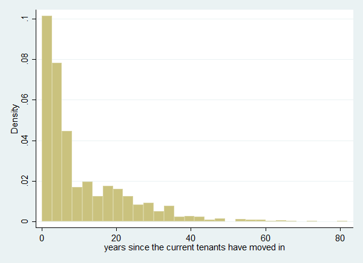

```stata
graph twoway histogram duration
```

```stata
reg rentp2m sqm sqmsq year yearsq centralheat hotwater loc_d1 loc_d3 bathtiles kitchen duration if bath == 0
```

```
      Source |       SS           df       MS      Number of obs   =     1,051
-------------+----------------------------------   F(11, 1039)     =     58.34
       Model |    10955.02        11  995.910905   Prob > F        =    0.0000
    Residual |  17735.2084     1,039  17.0694979   R-squared       =    0.3818
-------------+----------------------------------   Adj R-squared   =    0.3753
       Total |  28690.2283     1,050   27.324027   Root MSE        =    4.1315

------------------------------------------------------------------------------
     rentp2m |      Coef.   Std. Err.      t    P>|t|     [95% Conf. Interval]
-------------+----------------------------------------------------------------
         sqm |  -.1435406   .0160903    -8.92   0.000    -.1751138   -.1119675
       sqmsq |   .0004868   .0000902     5.40   0.000     .0003098    .0006637
        year |  -2.948725    .515468    -5.72   0.000    -3.960202   -1.937248
      yearsq |   .0007628   .0001333     5.72   0.000     .0005012    .0010243
 centralheat |   2.409708   .4102845     5.87   0.000     1.604627    3.214788
    hotwater |  -1.128957   .6863614    -1.64   0.100    -2.475769    .2178557
      loc_d1 |  -1.890101   .4690177    -4.03   0.000    -2.810431   -.9697706
      loc_d3 |   1.312825   .2916526     4.50   0.000     .7405302    1.885121
   bathtiles |   .8234578   .2805671     2.93   0.003     .2729151       1.374
     kitchen |   2.490536   .4447612     5.60   0.000     1.617804    3.363269
    duration |  -.1108656   .0113447    -9.77   0.000    -.1331268   -.0886045
       _cons |   2867.197   498.2419     5.75   0.000     1889.522    3844.872
------------------------------------------------------------------------------
```

Excluding the $31$ flats without separate bathroom does not change our estimates much.

```stata
reg rentp2m sqm sqmsq year yearsq bath centralheat hotwater loc_d1 loc_d3 bathtiles kitchen duration if duration <= 25
```

```
      Source |       SS           df       MS      Number of obs   =       958
-------------+----------------------------------   F(12, 945)      =     50.52
       Model |  10530.5033        12  877.541943   Prob > F        =    0.0000
    Residual |  16415.0976       945  17.3704736   R-squared       =    0.3908
-------------+----------------------------------   Adj R-squared   =    0.3831
       Total |  26945.6009       957  28.1563228   Root MSE        =    4.1678

------------------------------------------------------------------------------
     rentp2m |      Coef.   Std. Err.      t    P>|t|     [95% Conf. Interval]
-------------+----------------------------------------------------------------
         sqm |  -.1425239   .0164564    -8.66   0.000    -.1748192   -.1102286
       sqmsq |   .0005036   .0000918     5.49   0.000     .0003236    .0006837
        year |  -2.634346     .52849    -4.98   0.000    -3.671496   -1.597196
      yearsq |   .0006827   .0001366     5.00   0.000     .0004146    .0009508
        bath |  -1.165298   .9166693    -1.27   0.204    -2.964241    .6336446
 centralheat |    2.50945   .4386417     5.72   0.000     1.648626    3.370275
    hotwater |  -1.605427   .7286005    -2.20   0.028    -3.035289   -.1755645
      loc_d1 |  -2.190477   .4924091    -4.45   0.000    -3.156819   -1.224135
      loc_d3 |   1.268801   .3095631     4.10   0.000     .6612901    1.876311
   bathtiles |   .7521872   .3012999     2.50   0.013     .1608929    1.343482
     kitchen |   2.235658   .4504893     4.96   0.000     1.351583    3.119733
    duration |  -.2010175   .0205962    -9.76   0.000     -.241437   -.1605979
       _cons |   2559.094   510.9948     5.01   0.000     1556.278     3561.91
------------------------------------------------------------------------------
```

Excluding the very high duration flats doubles the coefficient on duration, other coefficients show only very small changes. The effect we find for `duration` is not driven by outliers, the very long duration outliers seem to mitigate the effect.

```stata
reg rentp2m sqm sqmsq year yearsq centralheat hotwater loc_d1 loc_d3 bathtiles kitchen duration if bath == 0 & duration <= 25
```

```
      Source |       SS           df       MS      Number of obs   =       934
-------------+----------------------------------   F(11, 922)      =     51.20
       Model |  9830.48254        11  893.680231   Prob > F        =    0.0000
    Residual |  16093.5797       922  17.4550756   R-squared       =    0.3792
-------------+----------------------------------   Adj R-squared   =    0.3718
       Total |  25924.0622       933  27.7857044   Root MSE        =    4.1779

------------------------------------------------------------------------------
     rentp2m |      Coef.   Std. Err.      t    P>|t|     [95% Conf. Interval]
-------------+----------------------------------------------------------------
         sqm |  -.1406612   .0166753    -8.44   0.000    -.1733872   -.1079352
       sqmsq |   .0004919   .0000928     5.30   0.000     .0003098    .0006739
        year |  -2.672154   .5345186    -5.00   0.000    -3.721169    -1.62314
      yearsq |   .0006924   .0001382     5.01   0.000     .0004212    .0009636
 centralheat |   2.475102   .4475347     5.53   0.000     1.596797    3.353407
    hotwater |  -1.170197   .7936054    -1.47   0.141     -2.72768    .3872855
      loc_d1 |   -2.21194   .4973088    -4.45   0.000    -3.187929   -1.235952
      loc_d3 |   1.240462   .3140452     3.95   0.000     .6241358    1.856789
   bathtiles |    .786214   .3028413     2.60   0.010     .1918757    1.380552
     kitchen |   2.249558   .4518234     4.98   0.000     1.362836     3.13628
    duration |  -.2027838   .0209752    -9.67   0.000    -.2439485   -.1616191
       _cons |   2595.987   516.8451     5.02   0.000     1581.658    3610.317
------------------------------------------------------------------------------
```

Again excluding bath does not really change anything.

## Do-file

The `do-file` for this exercise can be found [here](https://drive.google.com/open?id=1pd9Nor0Do-2d_GZ_mbrAFrfJzG5-ovKW).